# STutika_ST558_Project3

Sridhar Tutika

12/13/2019

# Principal Components Analysis (PCA)

Purpose of this project is to understand principal components in the data set using Unsupervised Learning models.Identifying Principal components will help develop the models by reducing the number of explanatory variables to important ones. And these Principal Components can be used to develop the regression Model. .

# Player Stats data

Source of the Data is NBA Player and Game data downloaded from [Kaggle](https://www.kaggle.com/schmadam97/nba-regular-season-stats-20182019#)

The source file contains around NBA stats from all games in all seasons from 2000-01 to 2018-19 season

# Principal Components in Player Stats data

Based on prcomp function, here we are finding relation/interaction between four key variables Salary, points Age and PER (efficiency rating of the player)

```
## Standard deviations (1, .., p=4):
## [1] 1.5111159 1.0234367 0.6643619 0.4772099
##
## Rotation (n x k) = (4 x 4):
##               PC1        PC2         PC3        PC4
## Salary -0.5544281  0.2258309 -0.67917557 -0.4246533
## Points -0.5866962 -0.2774092 -0.08595515  0.7559387
## Age    -0.2182907  0.8891358  0.35081643  0.1967602
## PER    -0.5484034 -0.2854506  0.63895234 -0.4577244
```

# Biplot - Visual for PCA

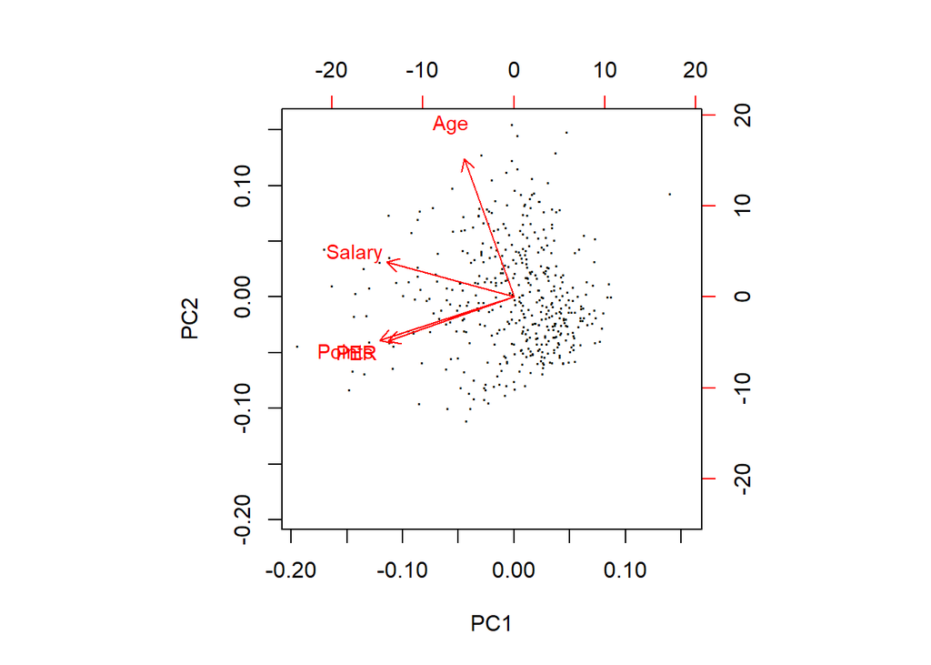

# Expanding the Analysis (More PCs)

Based on prcomp function, we are taking all the numeric variables from Age in the data set and finding the interactions with pairs function.

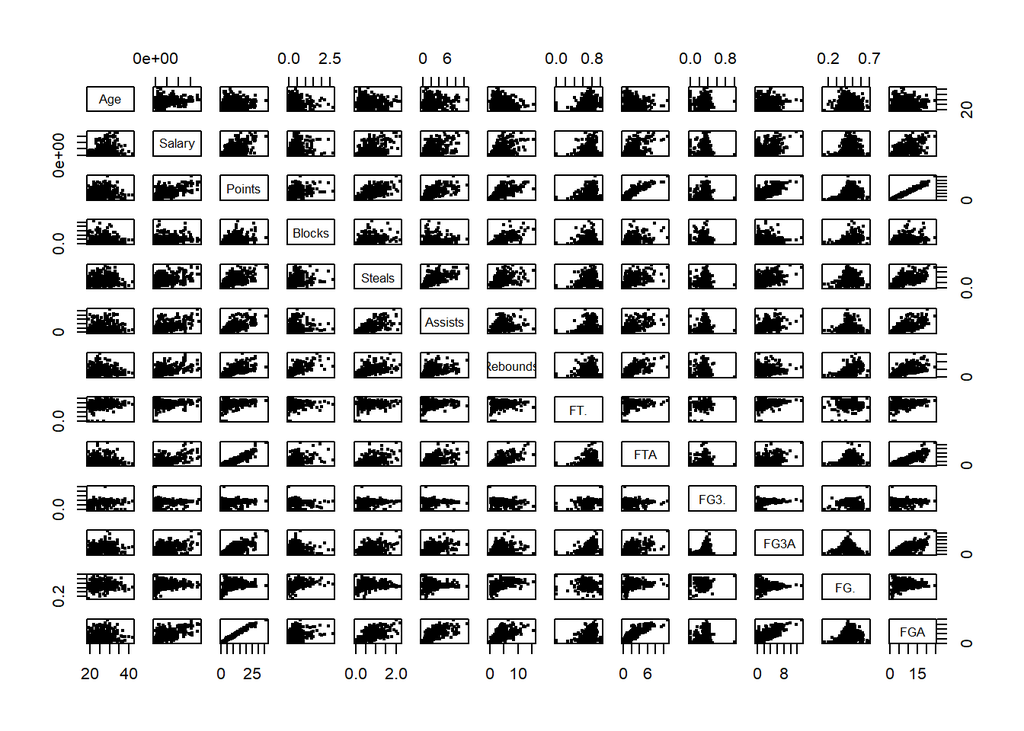

```
## Standard deviations (1, .., p=13):
##  [1] 2.36593022 1.46757188 1.07205833 1.03030276 0.80662594 0.79090102
##  [7] 0.75068602 0.59581563 0.57137728 0.49508480 0.42956672 0.28723164
## [13] 0.06684312
##
## Rotation (n x k) = (13 x 13):
##                  PC1          PC2         PC3         PC4         PC5
## Age      -0.06393791 -0.137151696  0.77991937 -0.39194145  0.05451681
## Salary   -0.31208469  0.001702977  0.26107688 -0.32476381  0.02061819
## Points   -0.40606232 -0.016592019 -0.09278844  0.07992266 -0.05035813
## Blocks   -0.19605243  0.437257935  0.11934579  0.18346891 -0.29356528
## Steals   -0.31666416 -0.031439500 -0.16923176 -0.15958317  0.23172121
## Assists  -0.31024361 -0.141433739 -0.15839457 -0.27355702  0.30168160
## Rebounds -0.29781720  0.377373249  0.07087260  0.10815074 -0.11622327
## FT.      -0.13252718 -0.338938677  0.30853124  0.39626493 -0.52083209
## FTA      -0.36795165  0.115051214 -0.11194141 -0.01599775 -0.12790528
## FG3.     -0.09893206 -0.377858842  0.15049601  0.56275943  0.47750112
## FG3A     -0.27238778 -0.404516765 -0.09530375  0.02664344 -0.09963965
## FG.      -0.11712677  0.431567539  0.28585971  0.33651094  0.46978626
## FGA      -0.39914453 -0.074406547 -0.14418857  0.03058753 -0.05840897
##                   PC6         PC7         PC8         PC9         PC10
## Age       0.062198554  0.03101644 -0.41240094  0.10324483 -0.133959989
## Salary    0.168988184  0.10758817  0.79524108 -0.14287444  0.187069875
## Points   -0.051440317  0.26012275 -0.12680303 -0.02527143  0.006652033
## Blocks    0.414064910 -0.34641220 -0.16392881  0.20056112  0.515589133
## Steals    0.033382834 -0.66455470 -0.07219500 -0.39672092 -0.277120399
## Assists  -0.377506272 -0.25119395 -0.05544348  0.46495545  0.324570262
## Rebounds  0.144834297 -0.05024204  0.06120417  0.10619260 -0.607850953
## FT.      -0.480832550 -0.28903246  0.15194439 -0.07048438  0.001139477
## FTA      -0.176720310  0.31086282 -0.02926901  0.30678200 -0.177599079
## FG3.      0.352793703 -0.04418857  0.14160938  0.33411994 -0.100994738
## FG3A      0.321289737  0.19781492 -0.26802774 -0.42346411  0.207639086
## FG.      -0.372387121  0.15762273 -0.07506030 -0.38905135  0.210359255
## FGA      -0.009134296  0.21549513 -0.14513258 -0.04258969  0.021240390
##                 PC11         PC12          PC13
## Age       0.07464166 -0.056170052  0.0007147777
## Salary    0.02198199 -0.009469917 -0.0045534300
## Points    0.08096679 -0.319215348  0.7885295923
## Blocks    0.10875511  0.001702093 -0.0085325107
## Steals    0.32961906 -0.004198607  0.0111997089
## Assists  -0.38423832  0.121302219  0.0156599850
## Rebounds -0.56375842  0.113055616 -0.0074177330
## FT.      -0.02708934  0.015743710 -0.0171986163
## FTA       0.55244639  0.481282062 -0.1761241958
## FG3.      0.10662790 -0.015396225 -0.0129895649
## FG3A     -0.28601817  0.470436776 -0.0519677733
## FG.      -0.04029824  0.111051059 -0.0752121862
## FGA      -0.02683389 -0.633703442 -0.5812568850
```

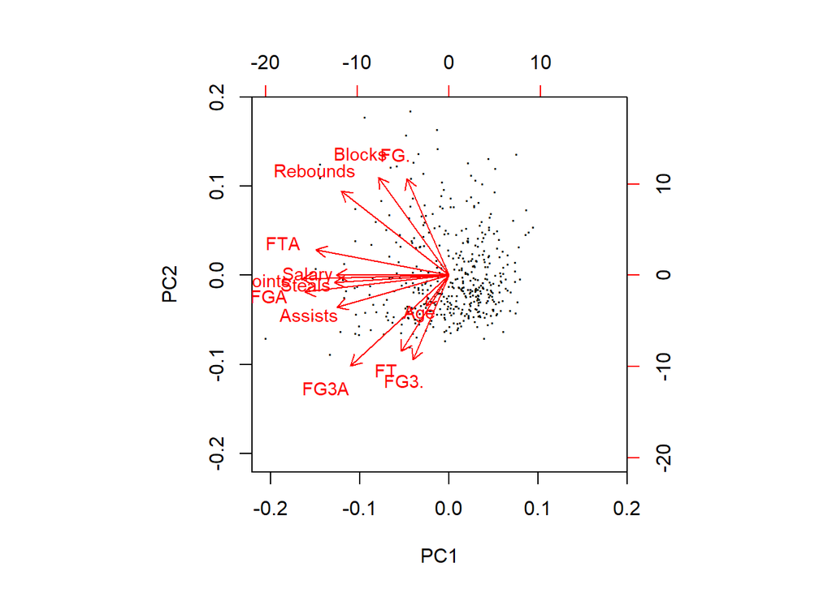

# Screeplot to determine Principal components

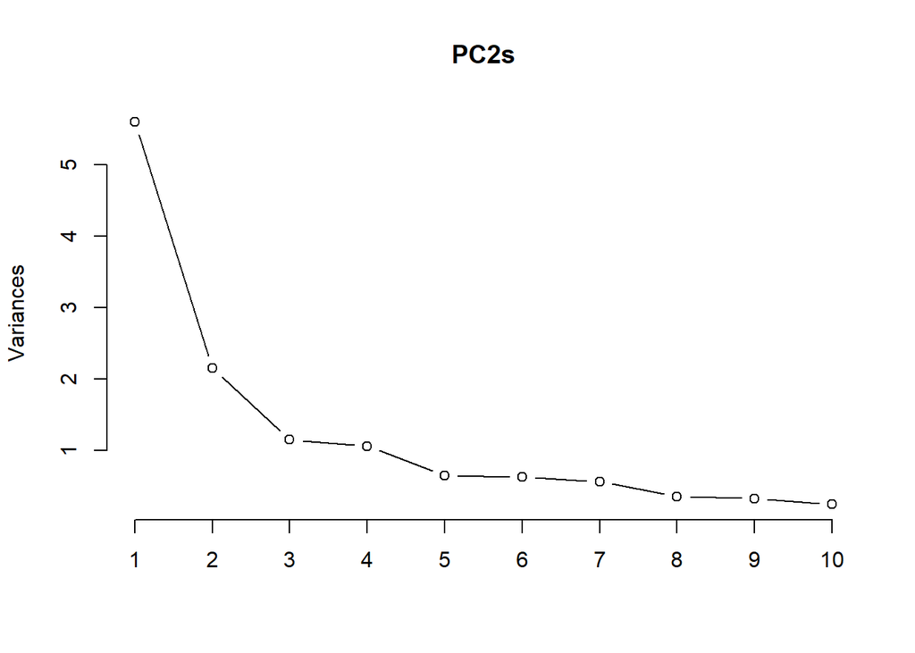